# InVivoStat Extended Paired t-test Analysis

## Response

The Resp 1 response is currently being analysed by the Extended Paired t-test Analysis and Within-Subject Analysis module. The response has been loge transformed prior to analysis.

## Case profiles plot of the observed data (on the loge scale)

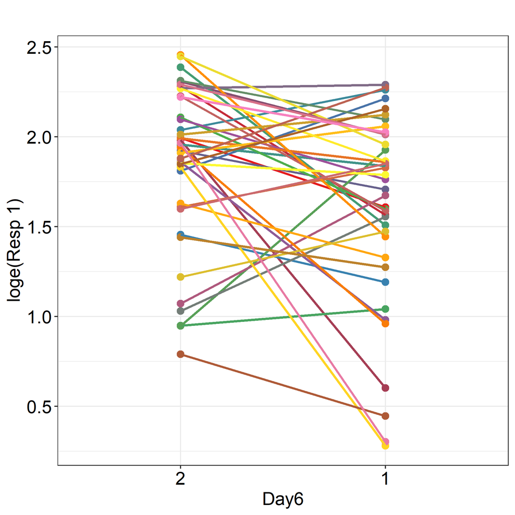

## Scatterplot of factor Day6 level 2 vs. level 1

(including a dotted line indicating the 1:1 relationship)

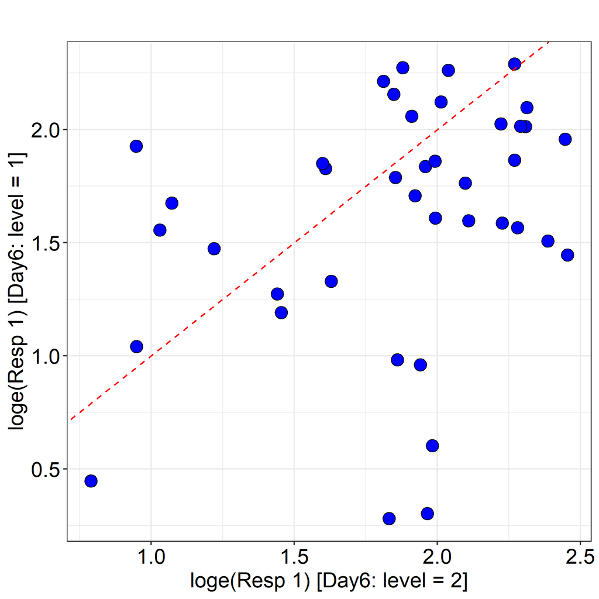

## Table of overall tests of model effects

| Effect | Num. degrees of freedom | Denom. degrees of freedom | F-value | p-value |
| --- | --- | --- | --- | --- |
| Block1 | 1 | 38.00 | 0.17 | 0.6792 |
| Day6 | 1 | 39.00 | 7.38 | 0.0098 |

Conclusion: At the 5% level there is a statistically significant overall difference between the levels of Day6.

Tip: While it is a good idea to consider the overall tests in the above table, we should not rely on them when deciding whether or not to make pairwise comparisons.

## Diagnostic plots

### Residuals vs. predicted plot

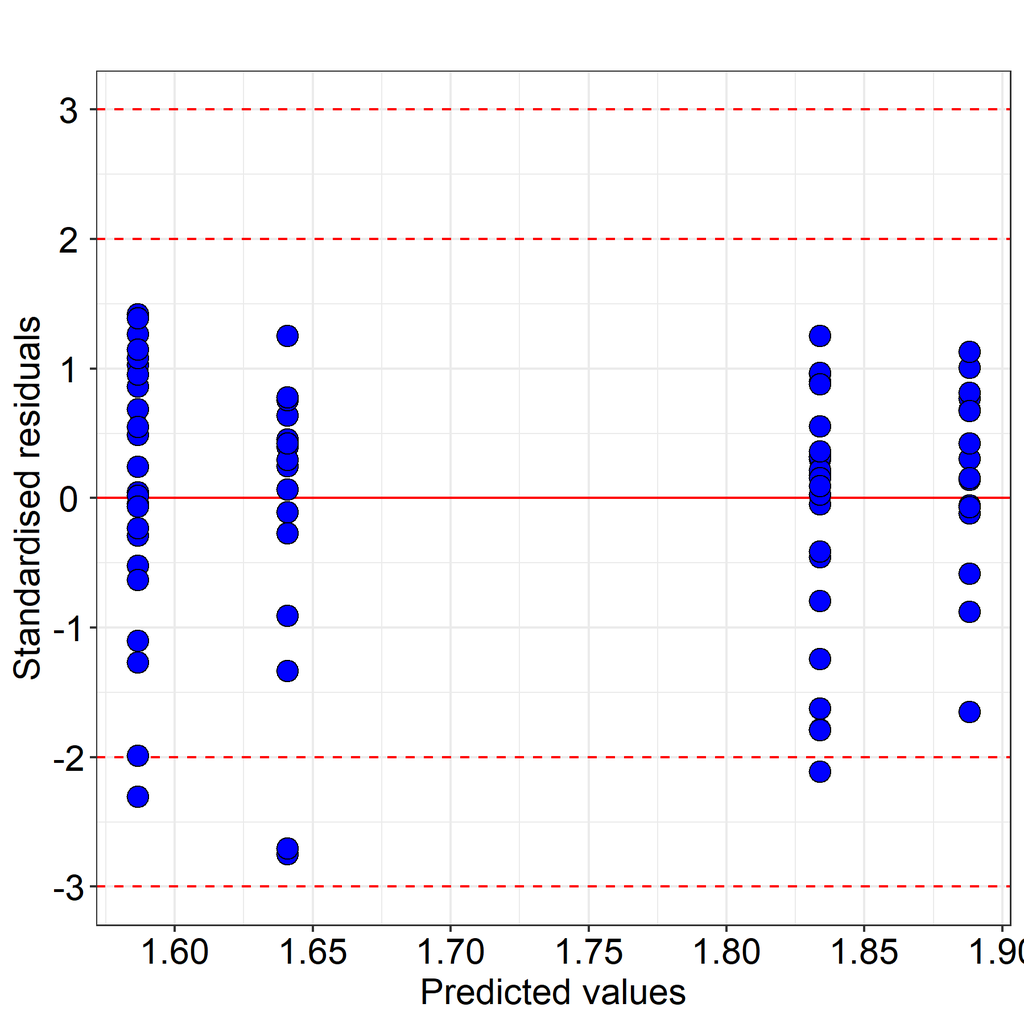

Tip: On this plot look to see if the spread of the points increases as the predicted values increase. If so the response may need transforming.

Tip: Any observation with a standardised residual less than -3 or greater than 3 (SD) should be investigated as a possible outlier.

Comment: The standardised residuals are obtained by subtracting the fitted values from the responses and dividing by the estimated within-group standard error.

### Normal probability plot

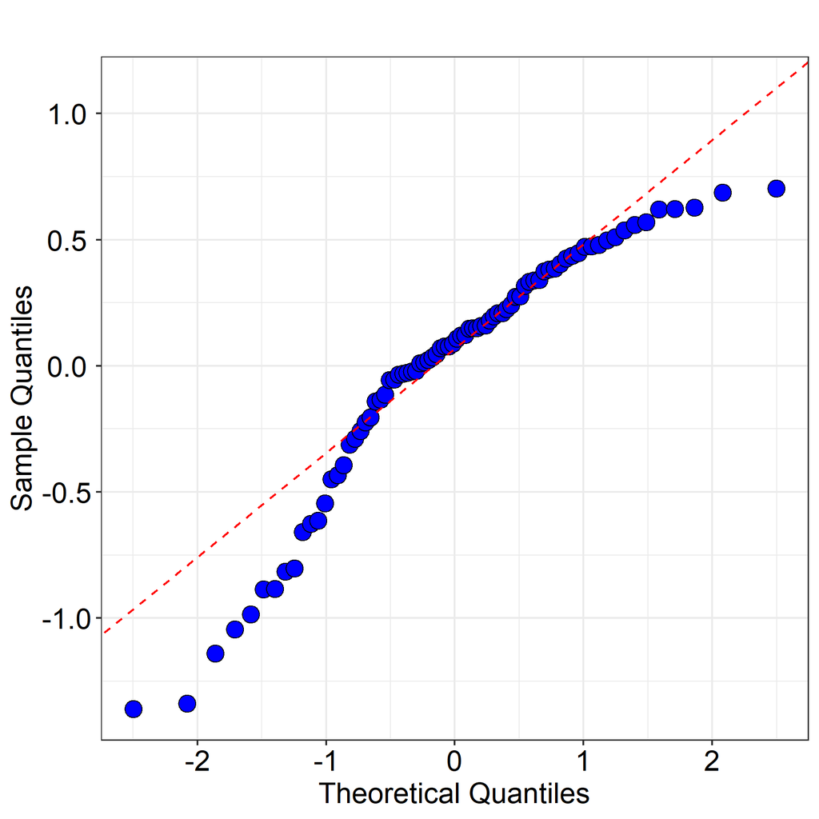

Tip: Check that the points lie along the dotted line. If not then the data may be non-normally distributed.

## Table of the least square (predicted) means with 95% confidence intervals

| Day6 | Mean | Lower 95% CI | Upper 95% CI |
| --- | --- | --- | --- |
| 2 | 1.861 | 1.703 | 2.019 |
| 1 | 1.614 | 1.455 | 1.772 |

## Plot of the least square (predicted) means with 95% confidence intervals

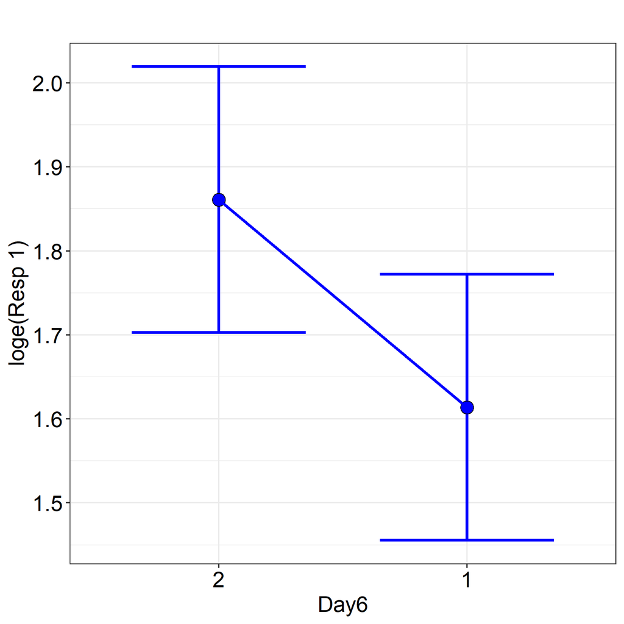

## Table of the back-transformed geometric means with 95% confidence intervals

As the response was log transformed prior to analysis the least square (predicted) means are presented on the log scale. These results can be back transformed onto the original scale. These are known as the back-transformed geometric means.

| Day6 | Mean | Lower 95% CI | Upper 95% CI |
| --- | --- | --- | --- |
| 2 | 6.430 | 5.488 | 7.532 |
| 1 | 5.021 | 4.286 | 5.882 |

## Plot of the back-transformed geometric means with 95% confidence intervals

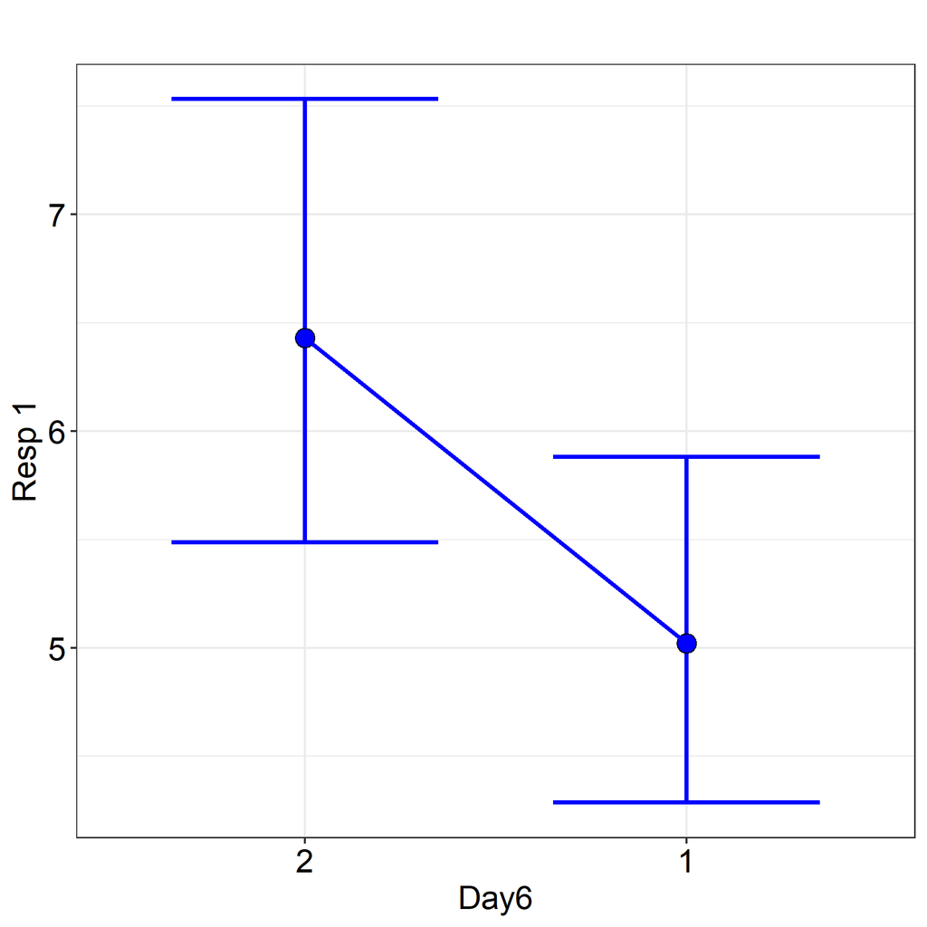

## All pairwise comparisons, without adjustment for multiplicity

| Comparison | Difference | Lower 95% CI | Upper 95% CI | Std error | p-value |
| --- | --- | --- | --- | --- | --- |
| ( 1 ) - ( 2 ) | -0.247 | -0.431 | -0.063 | 0.091 | 0.0098 |

## All pairwise comparisons, as back-transformed ratios

As the response was log transformed prior to analysis the differences between the least square (predicted) means are presented on the log scale. These results can be back-transformed, where differences on the log scale become ratios when back-transformed.

| Comparison | Ratio | Lower 95% CI | Upper 95% CI | p-value |
| --- | --- | --- | --- | --- |
| ( 1 ) / ( 2 ) | 0.781 | 0.650 | 0.939 | 0.0098 |

Conclusion: The pairwise comparison is statistically significant at the 5% level.

## Analysis description

The data were analysed using an extended paired t-test utilizing the mmrm R package, with treatment factor Day6 and Block1 as the blocking factor. The response was loge transformed prior to analysis to stabilise the variance.

The paired t-test performed by InVivoStat is defined as an extended paired t-test because the data is analysed using a repeated measures mixed model approach. This allows for any additional blocking factors and/or covariates to be taken into account as well as the pairing within the design.

The analysis implements the Kenward-Roger approximation of the degrees of freedom, see Kenward and Roger (1997).

For more information on the theoretical approaches that are implemented within this module, see Bate and Clark (2014).

## References

When referring to InVivoStat, please cite 'InVivoStat, version 5.2.0'.

Bate, S.T. and Clark, R.A. (2014). The Design and Statistical Analysis of Animal Experiments. Cambridge University Press.

Pinherio, J.C. and Bates, D.M. (2000). Mixed Effects Models in S and S-Plus. Springer-Verlag. New York, Inc.

Kenward, M.G. and Roger J.H. (1997). Small sample inference for fixed effects from restricted maximum likelihood. Biometrics. 983-997.

Venables, W.N. and Ripley, B.D. (2003). Modern Applied Statistics with S. 4th Edition; Springer. New York, Inc.